# Assignment_2_GROUP_4

Student 1: Jane Shadrina

Student 2: Paul Marie Mweni

Student 3: Moustafa Basiony

Student 4: Tolulope Soetan

2025-11-22

# Instructions

- Answer the questions below in this R Markdown file;
- Explain your coding decisions and output in detail;
- Knit the file to HTML;
- Send the knitted HTML file, together with the raw `rmd` file to Cecil.Meeusen@kuleuven.be;
- Make sure your documents are named like this: ‘Assignment_2_GROUP_X’;
- Don’t forget to fill out the group members names in the YAML header;
- This group assignment counts for 1 out of 20 grades;
- This is a GROUP assignment for groups consisting of 3-4 members. If you to not meet this guideline, this will result in a 0/1 for this assignment.
- You may receive questions about this assignment during the oral exam; if you do not submit this assignment, you may still receive questions about it during the oral exam.
- The use of GenAI is allowed, but should be clearly acknowledged in the designated section below. Be as transparent as possible. Unautherized use of genAI can have severe consequences. For guidelines see https://www.kuleuven.be/english/genai
- Your assignment will be evaluated based on following criteria:
  - Overall insight and depth
  - Correctness of answers
  - Coherence/logical composition/structure answers
  - Interpretation of results
  - Structure of code and annotations
  - Appropriate use of tables and visualisations
  - Appropriate use of genAI and course material

## Case/data description

Climate Migration Tweet Dataset (Synthetic Version)

**Acknowledgement: Thank you dra. Sercan Kiyak for generating the Tweet dataset and description of the data**

- Overview

This dataset is derived from an original Twitter collection focused on public discussions of climate migration (refugees displaced etc). The source data contained tweets referring to climate-induced displacement, refugees, and related political debates. From the original multilingual dataset, only three language groups were retained: • German (de) • Spanish (es) • Dutch (nl) These languages were chosen because they represented the largest clusters of activity in the corpus.

- Time Period

Tweets were filtered to the period between 15 November 2019 and 31 December 2019, during which the volume of conversation was highest. This timeframe includes two key climate-related events: • The COP25 conference (2-13 December 2019, originally planned in Chile, later held in Madrid) • The European Parliament’s declaration of a climate emergency (28 November 2019)

- Ethical Anonymization and Transformation

To make the data suitable for teaching and training, several steps were taken to fully anonymize and transform the texts:

1. Metadata removal: All identifiable user information such as usernames, mentions, and links were replaced with placeholders (. For example: Original tweet: “@Merkel @Junger wir in Europa Klimanotstand haben sind wir ja auch Klimaflüchtlinge. Wo können wir hin?” (fake tweet) Anonymized tweets: “[user] [link] wir in Europa Klimanotstand haben sind wir ja auch Klimaflüchtlinge. Wo können wir hin?”
2. Metadata retention: Only the following non-sensitive metadata were retained:
- date (tweet date)
- language (original tweet language)
3. Translation and paraphrasing: Tweets were translated into *English* and *paraphrased* to preserve meaning and tone while preventing traceability to the original text. This used `Llama3` for both tasks This process ensured that none of the resulting texts could be reverse-engineered to identify individual users.
- Synthetic Tweet Generation

To expand the dataset (we had about 1800 non-ReTweet tweets, to make them about 5000 in order to make the model training more reliable), synthetic tweets were generated (instead of collecting new tweets). Two locally run small language models (lightweight versions of AI text generators like GPT) were used to create artificial tweets that looked similar to real ones: * `Llama 3` (a small number of these were similar to paraphrased ones so deduplicated) * `Gemma 3` Each paraphrased tweet served as input to these models, which generated new, semantically related tweets inspired by the same topic and sentiment. The outputs were NOT reviewed fully. Moreover see the final section about the evaluation.

- Final Dataset
- Original tweets (after filtering): n = 1862
- Paraphrased and synthetic tweets combined: ≈ n = 5000
- Columns retained: *id (1 to X numbers)* *date* *language (the original text language)* *text (anonymised/synthetic text)*

The dataset thus contains both transformed (paraphrased) and model-generated (synthetic) examples mixed. No original text, usernames, or links are included.

- Limitations: Tone & Model Bias in Paraphrases/Synthetic Text

While the dataset aims to preserve the subject and stance of the original tweets, we observe a systematic tone shift introduced by the paraphrasing and synthetic generation steps. In particular: * Paraphrases and synthetic tweets skew more supportive of climate-migration and climate policy than the original discourse—especially in German (de), likely also in Dutch, where many tweets are in reality skeptical, ironic, or sarcastic. * This shift likely reflects alignment biases of the language models (LLMs), which tend to produce pro-refugee / pro-green framings and to smooth out sarcasm, irony, and antagonistic stances. * As a result, the transformed texts do not faithfully represent the full polarity present in the original timelines. They are best treated as didactic approximations for methods training—not as a ground-truth sample of public sentiment!

## Processing text

### Hashtags Exploration

1. Select all hashtags from the tweets. What are the 5 most frequentlt used hashtags?

   To select all the hashtags for the tweets we use the regular expression **#\\w+**.

```r
tweets <- read.csv('/Users/PaulMUTAMBA/Documents/Old Pc/KUL QASS/Collecting and Analysing for SDS/Assignements/tweets_final.csv')

tags <- tweets %>% mutate(tag=str_extract_all(text, "(#\\w+)")) %>%
  select(id, tag)

tags_long = tags %>% unnest(tag)

tags_long %>% group_by(tag) %>% summarise(counts = n()) %>% arrange(desc(counts)) %>% top_n(5)
```

```
## # A tibble: 5 × 2
##   tag               counts
##   <chr>              <int>
## 1 #ClimateRefugees    1744
## 2 #ClimateAction       643
## 3 #ClimateMigration    628
## 4 #ClimateJustice      442
## 5 #ClimateCrisis       439
```

#ClimateRefugees, #ClimateAction, #ClimateMigration, #ClimateJustice and #ClimateCrisis are the top 5 hastags used on the climate immigration tweets.

2. Plot the different hashtags using a visualisation of your choice

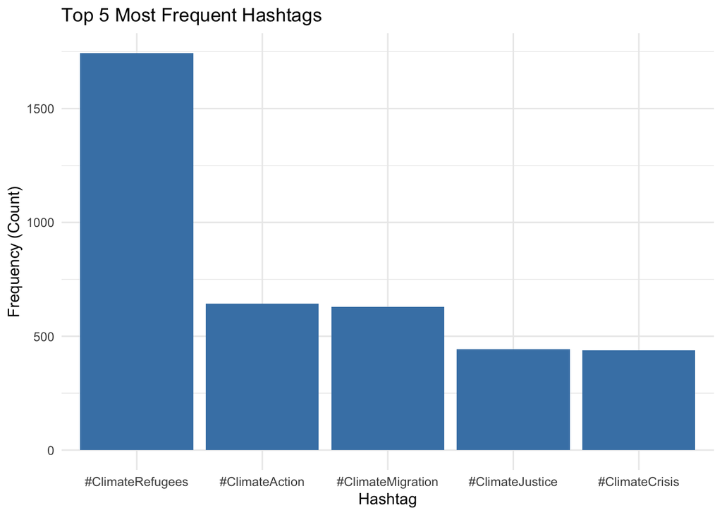

```r
tags_long %>% group_by(tag) %>% summarise(counts = n()) %>% arrange(desc(counts)) %>% top_n(5) %>% ggplot(aes(x = reorder(tag, -counts), y = counts)) +
  geom_col(fill = "steelblue") +
  labs(
    title = "Top 5 Most Frequent Hashtags",
    x = "Hashtag",
    y = "Frequency (Count)"
  ) +
  theme_minimal()
```

The barplot helps to better visualize the top 5 hashtags from the corpus. The #ClimateRefugees hastags - the most used hashtags, has been used almost three time more than #climateAction - the second most used hashtag. This may already tell something about the main theme of the corpus which we can assume based on the top hashtag is about to climate and refugees.

3. Compare the most used hashtags in the different languages (nl, de, es). What are your conclusions?

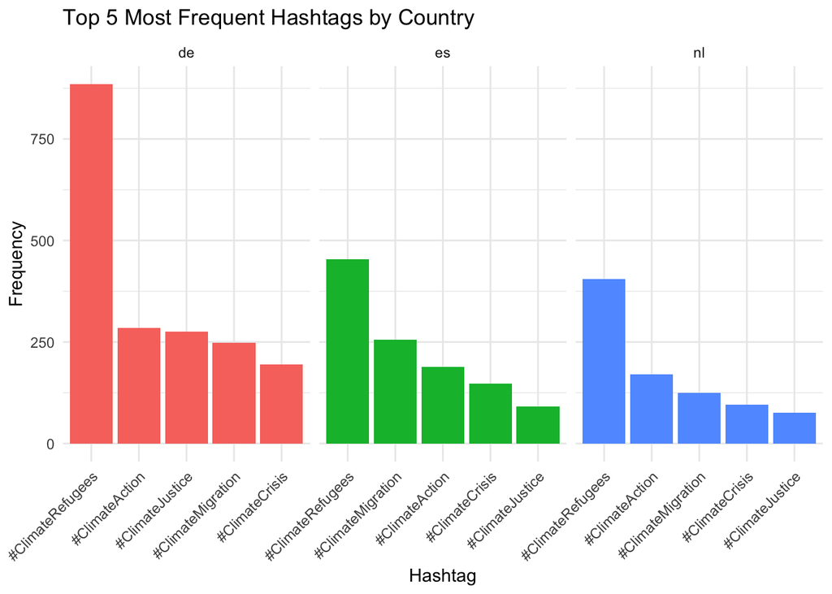

```r
tags_all_countries <- tweets %>%
  mutate(tag = str_extract_all(text, "(#\\w+)")) %>%
  select(id, language, tag) %>%
  unnest(tag)

# 2. Calculate counts and find top 5 PER language
top_tags_per_country <- tags_all_countries %>%
  group_by(language, tag) %>%
  summarise(counts = n(), .groups = "drop") %>%
  group_by(language) %>%
  slice_max(order_by = counts, n = 5) %>%
  ungroup() %>%
  # CRITICAL STEP for plotting facets correctly:
  # Create a unique tag ID so ggplot doesn't get confused if the same tag
  # appears in multiple countries with different ranks.
  mutate(unique_tag = paste(language, tag, sep = "_"))

# 3. Plotting
ggplot(top_tags_per_country, aes(x = reorder(unique_tag, -counts), y = counts, fill = language)) +
  geom_col(show.legend = FALSE) +
  # facet_wrap splits the graph by language.
  # scales = "free_x" allows each facet to have its own set of hashtags on the x-axis
  facet_wrap(~language, scales = "free_x") +
  # This cleans up the x-axis labels to remove the "de_" prefix we added earlier
  scale_x_discrete(labels = function(x) sub("^[a-z]+_", "", x)) +
  labs(
    title = "Top 5 Most Frequent Hashtags by Country",
    x = "Hashtag",
    y = "Frequency"
  ) +
  theme_minimal() +
  # Optional: rotate x-axis text if hashtags are long
  theme(axis.text.x = element_text(angle = 45, hjust = 1))
```

When viewing hashtags by country, it quickly becomes apparent that the three countries share the five most frequently used hashtags, but in a different order and with different distributions. For example, #climateRefugees is the most frequently used hashtag in all countries. It is particularly popular in Germany. #ClimateAction is the second most used hashtag in Germany and the Netherlands, which could suggest that in these two countries, those who tweet about climate migration are mainly inclined to call for action. In Spain, those who tweet about these topics are secondarily interested in the ‘climate migration’ dimension of the theme.

4. What are the most frequent collocations in your tweets? First, preprocess your corpus of tweets with different techniques you deem necessary. Explain all processing steps you applied and why you applied them. Second, cacululate the most frequent collocations in the tweets. Third, visualise your results. Are you surprised by the findings?

### Preprocessing

```r
clean_tweet_text <- function(text) {

  # Convert to lowercase
  text <- str_to_lower(text)

  # Remove [user] and [link]
  text <- str_remove_all(text, "\\[user\\]|\\[link\\]")

  # Remove URLs (http or https)
  text <- str_remove_all(text, "http\\S+|https\\S+")

  # Remove @mentions
  text <- str_remove_all(text, "@\\w+")

  # Remove hastags
  text <- str_remove_all(text, "#\\w+")

  #Remove single letter
  text <- str_remove_all(text, "\\b[a-z]\\b")

  # Remove everything that is not a letter (a-z), a space (\\s),
  # We replace them with a space to prevent words from sticking together.
  text <- str_replace_all(text, "[^a-z0-9\\s#']", " ")

  # Remove any extra spaces
  text <- str_squish(text)

  return(text)
}


cl_tweets <- tweets %>% mutate(cleaned_tweets = clean_tweet_text(text))

lema_tweets <- cl_tweets %>% unnest_tokens(words, cleaned_tweets) %>% filter(!words %in% c("let","isn","s","climate",stopwords("en"))) %>% mutate(lem = lemmatize_words(words)) %>% group_by(id) %>% summarise(lema_text = paste(lem, collapse = ' '))

tweets_df <- merge(x = cl_tweets, y = lema_tweets, by ="id", all.x = T)

head(tweets_df) %>%
  knitr::kable("html") %>%
  kableExtra::kable_styling(bootstrap_options = "striped", full_width = F) %>%
  kableExtra::scroll_box(width = "100%", height = "auto")
```

| id | date | language | text | cleaned_tweets | lema_text |
| --- | --- | --- | --- | --- | --- |
| 1 | 2019-11-15 | de | Rather than addressing the root issue, [USER] suggests a different approach to tackle the problem, questioning the effectiveness of current efforts | rather than addressing the root issue suggests different approach to tackle the problem questioning the effectiveness of current efforts | rather address root issue suggest different approach tackle problem question effectiveness current effort |
| 2 | 2019-11-15 | de | Let’s shift the focus – are we really tackling the *cause* or just symptoms? It feels like we’re putting out fires instead of stopping the blaze. #ClimateActionNow #SystemicChange | let’ shift the focus are we really tackling the cause or just symptoms it feels like we re putting out fires instead of stopping the blaze | shift focus really tackle cause just symptom feel like re putting fire instead stop blaze |
| 3 | 2019-11-15 | de | “Rather than patching up symptoms, let’s focus on uprooting the systemic issues driving #ClimateCrisis. We can’t keep treating the same old problems with the same old solutions 🌎 #ActOnClimate” | rather than patching up symptoms let’ focus on uprooting the systemic issues driving we can’ keep treating the same old problems with the same old solutions | rather patch symptom focus uproot systemic issue drive can keep treat old problem old solution |
| 4 | 2019-11-15 | es | “Climate action on the move: innovative solutions for refugees & vulnerable communities 🌎 #COP25 #ClimateJustice” | climate action on the move innovative solutions for refugees vulnerable communities | action move innovative solution refugee vulnerable community |
| 5 | 2019-11-15 | es | Efforts to combat climate change are being explored in refugee settings | efforts to combat climate change are being explored in refugee settings | effort combat change explore refugee setting |
| 6 | 2019-11-15 | es | Innovative climate solutions are emerging in refugee camps – a vital intersection of resilience & sustainability! Let’s support these initiatives & build a more just future. #ClimateAction #ClimateRef… | innovative climate solutions are emerging in refugee camps vital intersection of resilience sustainability let support these initiatives build more just future | innovative solution emerge refugee camp vital intersection resilience sustainability support initiative build just future |

A. We started by tokenising our tweets. This makes it easier to clean up, filter out stop words, and lemmatise each word.

B. Next, we cleaned the tokens. Below is an explanation of each cleaning step we used:

C. We lemmatized the cleaned tokens to reduce each word to its root form. This step was deemed necessary because it consolidates different inflected or derived variants of a word, thereby reducing the sparsity of the document–term matrix (DTM). Lemmatization also improves our ability to capture meaningful collocations and enhances the quality of subsequent topic modelling.

D. Finally, we gathered the cleaned and lemmatised tokens in a column named lema_text, which is the text field we will use to create our corpus.

### Collocations

```r
tweet_tokens = corpus(tweets_df, docid_field = "id",
                         text_field = "lema_text")

# dfm_bigram = tweet_tokens %>%
#   quanteda::tokens(remove_punct=T) %>%
#   quanteda::tokens_ngrams(1:2) %>%
#   dfm()


colloc = tweet_tokens %>%
  textstat_collocations(min_count = 10) %>% #min_count = minimum frequency of collocations that will be scored
  as_tibble()

colloc %>% arrange(-lambda) %>%
  head(10)
```

```
## # A tibble: 10 × 6
##    collocation       count count_nested length lambda     z
##    <chr>             <int>        <int>  <dbl>  <dbl> <dbl>
##  1 spin-dry corridor    14            0      2   12.8  8.54
##  2 clock tick           23            0      2   12.6  8.65
##  3 game changer         11            0      2   12.3  8.23
##  4 shed light           12            0      2   11.8  8.05
##  5 bear brunt           13            0      2   11.3  7.78
##  6 gain traction        18            0      2   11.3  7.81
##  7 ice cap              12            0      2   11.1  7.64
##  8 polar bear           10            0      2   10.9  7.47
##  9 claudia roth         34            0      2   10.7 12.6
## 10 mrs roth             14            0      2   10.5  7.25
```

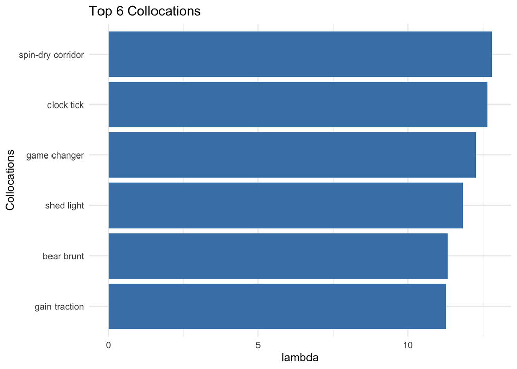

```r
 colloc %>% arrange(-lambda) %>%
  head(6) %>% ggplot(aes(x = reorder(collocation, lambda), y = lambda)) +
  geom_col(show.legend = FALSE,fill = "steelblue") + coord_flip() + theme_minimal() + xlab("Collocations") + labs(title = "Top 6 Collocations")
```

The collocation shows that the words ‘spin-dry’ and “corridor” tend to appear together. After a little research, we discovered that the ‘dry corridor’ is a dry tropical forest that is affected by climate change. But we didn’t understand where the prefix ‘spin’ came from. So we decided to delve deeper into our research on lemmatised tweets containing the word ‘spin-dry’.

```r
tweets_df[1773, ]$text
```

```
## [1] "\"Food insecurity grips Guatemala's Dry Corridor, with millions projected to be climate-displaced in Central America by 2050 🌊 #ClimateMigration #DisasterRelief\""
```

```r
tweets_df[1773, ]$cleaned_tweets
```

```
## [1] "food insecurity grips guatemala' dry corridor with millions projected to be climate displaced in central america by 2050"
```

```r
tweets_df[1773, ]$lema_text
```

```
## [1] "food insecurity grip guatemala spin-dry corridor million project displace central america 2050"
```

The original tweet correctly mentions ‘Dry corridor’, the cleaned tweet also correctly retains ‘dry corridor’, but the lemmatised version of the tweet adds the prefix “spin” to the adjective ‘dry’. This is surprising, as we would not expect such a change from the lemmatisation process. After some research, we discovered that the lemmatisation algorithm had confused the adjective ‘dry’ with the verb ‘dry’ (to dry clothes) and had therefore added the prefix “spin” to what it considered to be a verb in order to reduce the verb ‘dry’ to its root form.

5. What are the most frequent words associated with the word ‘refugee’?

```r
collocations = colloc %>%
  filter(lambda > 3) %>%
  pull(collocation) %>%
  phrase()

dfm_tweets_col <- tweet_tokens %>%
  quanteda::tokens(remove_punct=T) %>%
  tokens_tolower %>%
  tokens_compound(collocations) %>%
  dfm()

textstat_frequency(dfm_tweets_col) %>%
  filter(str_detect(feature, 'refugee'))
```

```
##                                           feature frequency rank docfreq group
## 1                                         refugee      1728    1    1690   all
## 204                               refugee_deserve        54  201      54   all
## 255                               welcome_refugee        45  249      45   all
## 258                               concept_refugee        44  257      44   all
## 266                                notion_refugee        42  266      42   all
## 743                              passport_refugee        17  707      17   all
## 785                       refugee_deserve_dignity        16  745      16   all
## 788                       german_passport_refugee        16  745      16   all
## 895                                refugee_status        13  885      13   all
## 940                    refugee_deserve_safe_haven        13  885      13   all
## 1027           refugee_receive_german_citizenship        12  947      12   all
## 1106                   refugee_deserve_protection        11 1028      11   all
## 1180                               refugee_arrive        10 1112      10   all
## 1183                               define_refugee        10 1112      10   all
## 1495                    refugee_deserve_attention         7 1456       7   all
## 1752                grant_german_passport_refugee         6 1606       6   all
## 2719 green_advocate_grant_german_passport_refugee         3 2299       3   all
## 3341              refugee_receive_german_passport         2 2850       2   all
## 3431                offer_german_passport_refugee         2 2850       2   all
## 3867                       concept_refugee_status         1 3553       1   all
## 4352                              refugee_receive         1 3553       1   all
## 4404       consider_grant_german_passport_refugee         1 3553       1   all
## 4508       notion_refugee_receive_german_passport         1 3553       1   all
## 4510       proposal_grant_german_passport_refugee         1 3553       1   all
## 4511       advocate_grant_german_passport_refugee         1 3553       1   all
## 4754                         refugee_deserve_safe         1 3553       1   all
```

The words frequently associated with the word ‘refugee’ indicate that the corpus takes a rather positive stance towards migration. Words such as ‘deserve’, ‘welcome’, “passport”, ‘deserve dignity’, ‘deserve a safe haven’, etc. show that most tweets call for positive action in favour of the migration cause.

## Sentiment analysis

### Vader Sentiment Analysis

1. Apply a sentiment analysis of your choice to the twitter corpus and plot the evolution of sentiment between 15 November 2019 and 31 December 2019. Explain how the sentiment package of your choice works. Apply all preprocessing steps you deem necessary. Interpret your results. Do not use the dictionaries of the book Computational Communication Science. Tip: Make sure to remove the meta-data placeholders like [USER] [LINK]
- Preprocessing:

For the “vader” package specifically, less preprocessing than usual is required. In the following chunk, we are removing placeholders/stray URLs, retweets markers, and replacing hashtags with words.

```r
data_vader <- read_csv('/Users/PaulMUTAMBA/Documents/Old Pc/KUL QASS/Collecting and Analysing for SDS/Assignements/tweets_final.csv') %>%
  mutate(
    text = as.character(text),
    text = iconv(text, to = "UTF-8", sub = ""),
    text = str_replace_all(text, "\\[(USER|LINK)\\]", " "),
    text = str_replace_all(text, "\\bhttps?://\\S+", " "),
    text = str_replace_all(text, "^RT\\s+", " "),
    text = str_replace_all(text, "(^|\\s)#([\\p{L}\\p{N}_]+)", "\\1\\2"),
    text = str_squish(text)
  ) %>%
  filter(!is.na(text), text != "") %>%
  distinct(id, text, .keep_all = TRUE)
```

**Selection sentiment package**

Considering the nature of our dataset (twitter corpus, climate migration topic) and goals (sentiment analysis), the following packages **were considered**:

- just **“tidytext”** and its lexicons (not chosen):

This is one of the more simple and straightforward ways of conducting sentiment analyses as of now, given that this package does not offer any built-in ways of handling negations, punctuation nuances, emojis, caps, amplifiers, etc.

The good thing about this option is that there are different lexicons available (“nrc”, “afinn”, “bing”, “loughran”) — but we are excluding “nrc” as it is used in the following task and “loughran” since it claims to be developed for financial contexts specifically, — which leaves us with “afinn” and “bing”.

Technically, we could employ both of them in our context, since “afinn” dictionary was specifically developed for the twitter context, and “bing” is a roughly “all-purpose” lexicon (though it was initially created for customer reviews).

But nonetheless, it would still be interesting to try and take into account negations, punctuation, emojis, and other potential features. Thus, unless we want to build our own set of rules (which might be quite complicated and not necessarily worth the effort in terms of the resulting classification quality), we might as well prefer other options.

- **sentimentr** (not chosen):

This is one of the more advanced packages that has the ability to comprehend negations, amplifiers, de-amplifiers, etc. natively. It also offers the flexibility to use different lexicons (including the ones mentioned above that generally fit our goals, the base lexicon is “bing” + “syuzhet” combined).

Punctuation, elongated words, caps usage are not treated automatically on the other hand. Unless we extend our dictionaries and create tokens for those features, they will not affect the analysis — which is already not by any means bad, but there are still more ideal packages that have those features built-in intrinsically.

- **sentiStrengthR** (not chosen):

This is one of the two most advanced packages we could use for our analysis. sentiStrengthR employs negations, amplifiers, punctuation, repeated letters, emoji, etc. Its dictionary is specifically designed for short informal texts with continuous pos/neg strengths attributed to each token. sentiStrengthR was generally a viable option, however another package was preferred the for reasons stated below.

- **vader**:

This is the second most advanced package, and also **our package of choice**. It handles ~nearly everything that sentiStrengthR handles, and a bit more (for instance, this package is supposed to be a bit more familiar with slang and complex grammatical constructions). Its dictionary contains more than 7500 tokens and is specifically tuned for the microblogs contexts. Vader also allows to add tokens to the vocabulary, as opposed to the sentiStrengthR.

**How does it work?**

Answer:

“Vader” package a dictionary(or rule)-based approach to sentiment analysis.

It has a built-in manually labelled dictionary with more than 7500 tokens, suitable for microblog context. Addition of other tokens is possible, but the documentation authors advise to have 10 people label any given new token independently, and only add tokens whose standard deviation doesn’t exceed 2.5

VADER follows the following steps in the implementation

1. Sums all the valence scores of each word in the lexicon;
2. Adjusts it according to the inner rules set (including the handling of punctuation, caps, emojis, degree modifiers, negations, slang/abbreviations, contrastive conjunctions);
3. Normalizes the score to be between -1 and 1.

Typical thresholds for classification mentioned in the documentation.

if score >= 0,05 -> positive; if score <= -0,05 -> negative; else: neutral.

Sources: — https://vadersentiment.readthedocs.io/en/latest/index.html

#### **Why is it not a good idea to use the sentiment dictionary of the books website?**

Answer:

This dictionary has a binary division on positive and negative words, is pretty general, and also not really big in volume (around ~3600 words for negative and ~2000 for positive categories, respectively). It is not a good idea to use it for a number of reasons.

Firstly, this particular dictionary doesn’t fit our context of the climate migration tweets dataset precisely enough — we could benefit from something a little more intricate. In the grand scheme of things, we would want our dictionary/set of rules to be specifically tuned for our usage context to get the best possible accuracy out of our dictionary approach. There’s no reason to expect this dictionary to perform better than the ones specifically tuned for the microblogs context, or the ones bigger in size.

Another question that could be raised is the methodology of this dictionary. How many people had to agree on the positive/negative words’ labels for it to be finalized? We couldn’t find any information regarding this, so naturally it is also a point of concern — if it was labelled in its entirety by only one person, the bias might be too serious.

#### **Sentiment analysis:**

Let’s now apply vader to our preprocessed data.

Even though vader performs tokenization on its own, we are additionally tokenizing entire tweets by sentences to ensure that each sentence has equal weight in the final calculation of a given tweet’s sentiment.

Otherwise, an overwhelmingly positive or negative sentence may throw off the score of a tweet as a whole. But this step is more of a researcher’s preference — we decided to do it, and others might decide against it.

Our thresholds for the initial run are the ones recommended in vader documentation.

```r
# Let's build a function that tokenizes tweets by sentences and calculates average compound score for each sentence in one tweet

vader_compound_mean <- function(x) {
  sents <- tokenize_sentences(x, strip_punct = FALSE, simplify = TRUE)
  if (length(sents) == 0) return(NA_real_)
  sc <- sapply(sents, function(s) as.numeric(get_vader(s)["compound"]))
  mean(sc, na.rm = TRUE)
}

# Running vader itself
data_vader <- data_vader %>%
  rowwise() %>%
  mutate(vader_compound = vader_compound_mean(text)) %>%
  ungroup() %>%
  mutate(
    # Let's try package recommended thresholds
    vader_label = case_when(vader_compound >= 0.05 ~ "positive", vader_compound <= -0.05 ~ "negative", TRUE ~ "neutral"))


data_vader %>% count(vader_label)
```

```
## # A tibble: 3 × 2
##   vader_label     n
##   <chr>       <int>
## 1 negative     2886
## 2 neutral       940
## 3 positive     1656
```

**Interpretation**: vader concluded that there are 2886 negative, 1656 positive, and 940 neutral tweets. Neutral category looks suspiciously small so let’s perform a quick validation.

##### **Validation:**

335 tweets were sampled from the entire dataset and then human-labelled as either negative, neutral, or positive (it’s a rather primitive check, we were only aiming at 10% CI).

```r
# A little clean-up function because we found weird excel artefacts in some cells in our validation file
canon_label <- function(x) {
  x <- as.character(x)
  x <- str_replace_all(x, "\u00A0", " ")
  x <- str_squish(tolower(x))
  x <- recode(x, "pos" = "positive", "neg" = "negative", "neu" = "neutral", .default = x)
  factor(x, levels = c("negative","neutral","positive"))
}

# Validation_vader is the inital dataset but with 335 added human labels
val <- read_excel("validation_vader.xlsx") %>%
  slice(1:335) %>%
  filter(!is.na(human_label)) %>%
  mutate(human_label = canon_label(human_label), vader_label_excel = canon_label(vader_label_pred))

# Confusion matrix
cm <- conf_mat(val, truth = human_label, estimate = vader_label_excel)
kable(cm$table, caption = "Confusion matrix (rows = observed, cols = predicted)")
```

Confusion matrix (rows = observed, cols = predicted)

|  | negative | neutral | positive |
| --- | --- | --- | --- |
| negative | 125 | 48 | 20 |
| neutral | 9 | 30 | 11 |
| positive | 11 | 33 | 48 |

```r
# Accuracy, Cohen's k, precision, recall, f1 (using macro estimators as each label is equally important to us)
overall_metrics <- bind_rows(
  accuracy(val, truth = human_label, estimate = vader_label_excel),
  kap(val, truth = human_label, estimate = vader_label_excel),
  precision(val, truth = human_label, estimate = vader_label_excel, estimator = "macro"),
  recall(val,    truth = human_label, estimate = vader_label_excel, estimator = "macro"),
  f_meas(val,    truth = human_label, estimate = vader_label_excel, estimator = "macro"))
overall_metrics
```

```
## # A tibble: 5 × 3
##   .metric   .estimator .estimate
##   <chr>     <chr>          <dbl>
## 1 accuracy  multiclass     0.606
## 2 kap       multiclass     0.381
## 3 precision macro          0.590
## 4 recall    macro          0.580
## 5 f_meas    macro          0.558
```

**Interpretation**:

The overall accuracy is around 0.6, which is not bad. Precision is around 0.59 — around 59% of tweets’ classes are predicted correctly (on average); recall is around 0.58 — around 58% of true items in a class are recovered.

F-statistic is around 0.56 — not too bad as well (however we can see a drop from the other statistics, which means that we have problematic labels — “neutral” and “positive” have weaker quality of prediction, and it reflects in the CM as well). Cohen’s k is around 0.38, thus implies that vader still works better than random assignment of labels based on their relative “appearance chance” proportion.

In sum, our concerns about “neutral” category were justified (it is indeed problematic), however the labels themselves are not awful and still usable so we can proceed to the next task and interpret our outputs comfortably.

#### **Evolution over time**

Important climate-related events from the dataset description:

- COP25 conference (2-13 December 2019);
- European Parliament’s declaration of a climate emergency (28 November 2019).

Let’s take a look the evolution of predicted sentiments over time.

We will start with **daily mean vader sentiments** (overall scores):

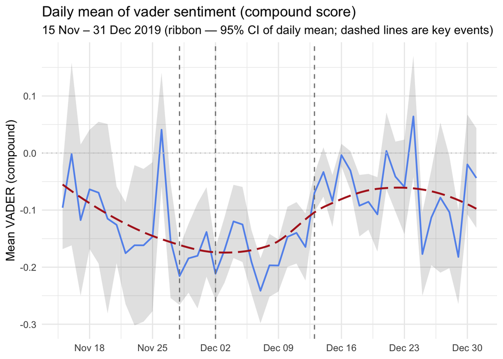

```r
# Choosing time range
data_vader <- data_vader %>%
  mutate(date = as.Date(date)) %>%
  filter(date >= as.Date("2019-11-15"), date <= as.Date("2019-12-31"), !is.na(vader_compound))


# Calculating means with 95% CI ribbon for the daily mean (normal approximation)
daily <- data_vader %>%
  group_by(date) %>%
  summarise(n = n(),
    mean_compound = mean(vader_compound, na.rm = TRUE),
    sd = sd(vader_compound, na.rm = TRUE),
    se = sd / sqrt(n),
    ci95 = 1.96 * se, .groups = "drop") %>%
  arrange(date) %>%
  mutate(roll7 = rollapply(mean_compound, width = 7, align = "right", fill = NA, FUN = mean, na.rm = TRUE))

# Our key events
events <- tibble(date  = as.Date(c("2019-11-28","2019-12-02","2019-12-13")))

# Making a visualisation of compound scores
p_daily <- ggplot(daily, aes(x = date, y = mean_compound)) +
  geom_ribbon(aes(ymin = mean_compound - ci95, ymax = mean_compound + ci95), alpha = .15) +
  geom_line(color = "cornflowerblue", linewidth = 0.8) +
  geom_smooth(color = "firebrick", method = "loess", se = FALSE, linewidth = 0.9, linetype = "longdash") +
  geom_hline(yintercept = 0, color = "grey80", linetype = "dotted") +
  geom_vline(data = events, aes(xintercept = date), linetype = "dashed", color = "grey50") +
  scale_x_date(date_breaks = "1 week", date_labels = "%b %d") +
  labs(title = "Daily mean of vader sentiment (compound score)", subtitle = "15 Nov – 31 Dec 2019 (ribbon — 95% CI of daily mean; dashed lines are key events)", x = NULL, y = "Mean VADER (compound)") +
  theme_minimal(base_size = 12)

p_daily
```

**Interpretation**:

As we can see, in the period from 15/11/2019 to 31/12/2019, the daily mean scores are, for the most part, below 0.0 (most often sitting at [−0.10; −0.15]). It implies that the sentiment during this time period was, for the most part, mildly negative.

At the 28th of November (EP’s declaration of a climate emergency), we can see one of the lowest dips of a mean sentiment, and up until around 13th of December (near to the end of COP25) the sentiment remained overwhelmingly negative, and had even lower dips thorough.

After that, we can see that mean sentiment was getting not as negative. With many ribbons touching 0.0, we can even say that it got somewhat close to being neutral.

Even though the proportion of positive tweets increased in the late December, the mean is still close to zero because negative tweets are intensely negative, and positive tweets are generally only modestly positive.

Let’s also look at the **daily proportions of labels**:

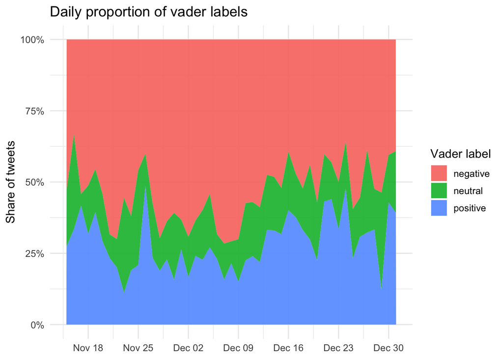

```r
# Making a visualisation of labels

byday_label <- data_vader %>%
  count(date, vader_label, name = "n") %>%
  group_by(date) %>%
  mutate(prop = n / sum(n)) %>%
  ungroup()

p_prop <- ggplot(byday_label, aes(x = date, y = prop, fill = vader_label)) +
  geom_area(alpha = .9) +
  scale_y_continuous(labels = percent_format(accuracy = 1)) +
  scale_x_date(date_breaks = "1 week", date_labels = "%b %d") +
  labs(title = "Daily proportion of vader labels", x = NULL, y = "Share of tweets") +
  theme_minimal(base_size = 12) +
  guides(fill = guide_legend(title = "Vader label"))

p_prop
```

### NRC Sentiment Analysis

2. Apply the `nrc` sentiment analysis to the twitter data and compare the sentiments between originally Dutch, Spanish and Germans tweets. Interpret your results

For the NRC sentiment analysis, all preprocessing steps (cleaning, tokenization, stop word removal, and lemmatization) were identical to those in the first section. We deemed them appropriate for the NRC sentiment analysis. Therefore, since the `lema_text` column (used for collocations) already contains the cleaned and lemmatized text, we do not perform any further preprocessing and use `lema_text` directly.

```r
## Loading required libraries
library(tidyverse)
library(lubridate)
library(stringr)
library(tidytext)
library(ggplot2)
library(scales)
library(syuzhet)

# Filtering those rows where the lemmatized text is missing or empty,
# and ensuring that only valid text entries are
# used for the nrc sentiment analysis.

tweets_nrc <- tweets_df %>%
  filter(!is.na(lema_text), lema_text != "")


# The nrc sentiment scores
nrc <- tweets_nrc %>%
  mutate(nrc = map(lema_text, ~get_nrc_sentiment(.x))) %>%
  unnest(cols = c(nrc))


# inspecting the first 10 nrc categories
# colnames(nrc)

# proofing the 10 nrc categories
colnames(nrc)
```

```
##  [1] "id"             "date"           "language"       "text"
##  [5] "cleaned_tweets" "lema_text"      "anger"          "anticipation"
##  [9] "disgust"        "fear"           "joy"            "sadness"
## [13] "surprise"       "trust"          "negative"       "positive"
```

```r
# Comparing the sentiment scores between Dutch, Spanish and Germans tweets
# Aggregating the sentiment by language and reshaping for plotting

nrc_lang <- nrc %>%
  group_by(language) %>%
  summarise(across(anger:positive, sum, na.rm = TRUE)) %>%
  pivot_longer(-language, names_to = "category", values_to = "count")

### display first 10 sentiment counts by language
head(nrc_lang, 10)
```

```
## # A tibble: 10 × 3
##    language category     count
##    <chr>    <chr>        <dbl>
##  1 de       anger         1899
##  2 de       anticipation  2122
##  3 de       disgust        614
##  4 de       fear          3234
##  5 de       joy           1204
##  6 de       sadness       2570
##  7 de       surprise      1334
##  8 de       trust         2764
##  9 de       negative      5118
## 10 de       positive      5368
```

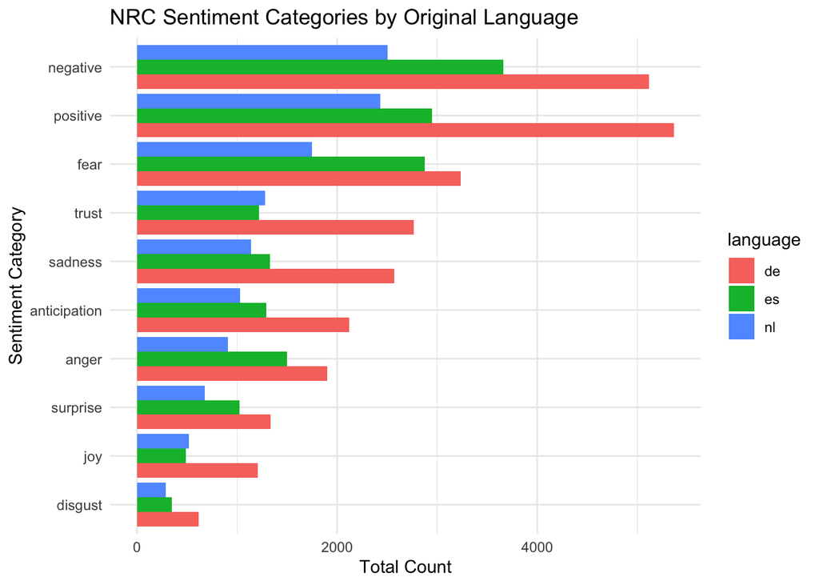

```r
# Plot comparison
ggplot(nrc_lang, aes(x = reorder(category, count), y = count, fill = language)) +
  geom_col(position = "dodge") +
  coord_flip() +
  labs(title = "NRC Sentiment Categories by Original Language",
       x = "Sentiment Category",
       y = "Total Count") +
  theme_minimal()
```

**Interpretation**: The NRC sentiment analysis shows that German tweets display slightly more positive than negative sentiment, suggesting a cautiously optimistic tone, although words associated with fear and sadness still appear frequently. In contrast, Spanish tweets are more negative overall, with fear and anger being the dominant emotions, indicating concern or criticism. Dutch tweets also lean slightly negative, with fear, trust, and positive sentiments being the most common. Overall, fear is a pervasive emotion across all three languages: German tweets are mildly positive, while Spanish and Dutch tweets tend to show more negativity.

## Topic modeling

### How Many Topics?

As mentioned earlier, the same pre-processing pipeline used for the collocation stage is applied for theme modelling. We felt that removing hashtags and punctuation marks from the corpus helped to reduce noise that could affect the theme modelling process. Therefore lemmatised text was used as the text field for the corpus used for the topic modelling.

```r
tweet_corpus = corpus(tweets_df, docid_field = "id",
                         text_field = "lema_text") %>%
  quanteda::tokens(remove_punct=T) %>%
  tokens_tolower %>%
  dfm() %>%
  dfm_trim(min_docfreq = 5, docfreq_type = "count")

library(topicdoc)
library(topicmodels)

results1 = list()
dtm = convert(tweet_corpus, to="topicmodels")

# We define our parameters
seeds_to_test <- c(123, 91, 42) # Three seeds randomly chosen
k_values <- c(2, 4, 8, 10, 12)    # The K-values

results_list <- list()

#For each seed we ran the LDA with different K topics
for (s in seeds_to_test) {
  for (k in k_values) {

    alpha <- 1 / ((1:k) + sqrt(k))

    lda <- LDA(dtm, k = k, control = list(seed = s, alpha = alpha))

    results_list[[paste(s, k, sep = "_")]] <- data.frame(
      seed = s,
      k = k,
      perplexity = perplexity(lda),
      coherence = mean(topic_coherence(lda, dtm)),
      exclusivity = topic_exclusivity(lda)
    )
  }
}

# We Combine all results into one big data frame
all_results_df <- bind_rows(results_list)
```

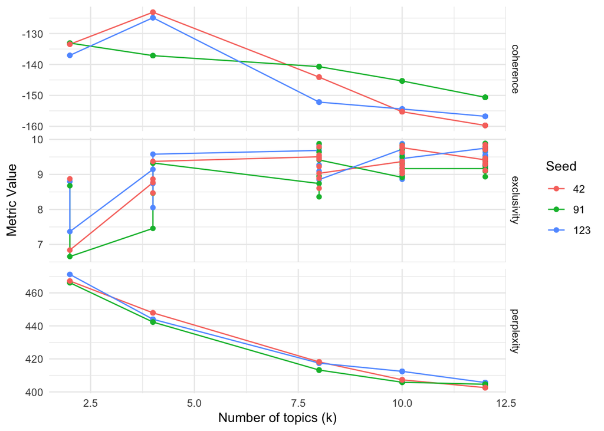

```r
# We Pivot the data into a long format for ggplot
results_long <- all_results_df %>%
  pivot_longer(
    cols = c(perplexity, coherence, exclusivity),
    names_to = "metric",
    values_to = "value"
  )


ggplot(results_long, aes(x = k, y = value, color = as.factor(seed), group = as.factor(seed))) +
  geom_line() +
  geom_point() +
  xlab("Number of topics (k)") +
  ylab("Metric Value") +
  labs(color = "Seed") +
  facet_grid(metric ~ ., scales = "free_y") +
  theme_minimal()
```

Our goal is to achieve a high consistency and exclusivity score, along with a minimal perplexity score. The graph of the three metrics shows that k = 4 offers the best compromise with a seed number of 123.

With a seed of 42, the best compromise between the three metrics is again k = 4. It appears that our corpus of tweets on climate immigration presents four main discussion themes. The next steps involve exploring and interpreting these four themes, and analyzing their relevance and significance to the corpus.

### **Running LDA**

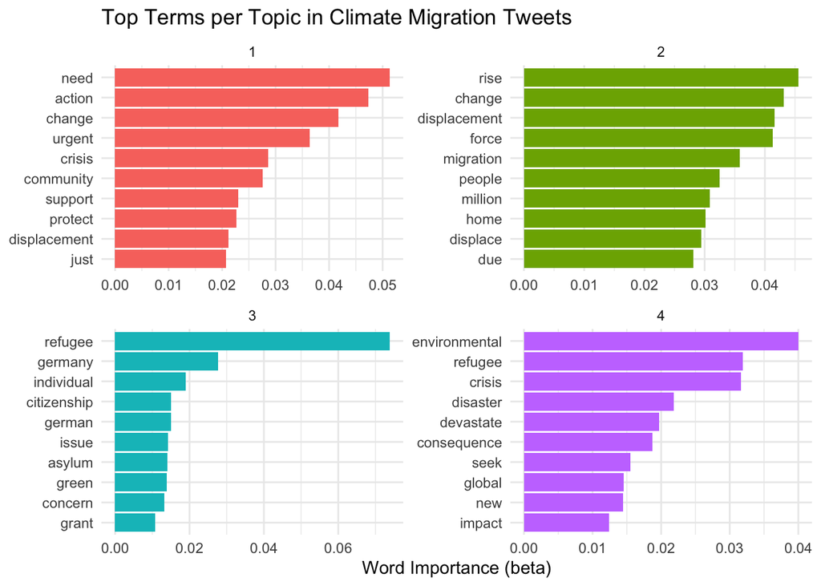

```r
lda <- dtm %>% LDA(k=4, control = list(seed=123, alpha=1/1:10))

df_terms <- tidy(lda, "beta") ## beta score


df_top <- df_terms |>
  group_by(topic) %>%
  slice_max(n = 10, beta) %>%
  ungroup() %>%
  arrange(topic, beta) %>%
  mutate(order = row_number())

df_top %>%
  mutate(term = reorder_within(term, beta, topic)) %>%
  ggplot(aes(beta, term, fill = factor(topic))) +
  geom_col(show.legend = FALSE) +
facet_wrap(~topic, scales = "free") +
scale_y_reordered() +
labs(
title = "Top Terms per Topic in Climate Migration Tweets",
x = "Word Importance (beta)",
y = NULL) +
theme_minimal()
```

### Topic Interpretation

```r
topics <- posterior(lda)$topics %>%
  as_tibble() %>%
  rename_all(~paste0("Topic_", .))

tweets_topics <- bind_cols(tweets, topics)

tweets_topics %>%
  arrange(desc(Topic_1)) %>%
  slice_head(n = 10) %>% select(text)
```

```
##                                                                                                                                                                                                                              text
## 1            The devastating human cost of climate change – displacement, melting ice, and more – is a major focus at #COP25 in Madrid. We need urgent action to protect vulnerable communities and our planet. 🌎 #ClimateCrisis
## 2                                   Just watched a powerful documentary exposing the horrific reality of climate change – we’re running out of time! 🌍 Urgent action is needed NOW to protect our planet. #ClimateCrisis #ActNow
## 3  The escalating climate crisis isn't just about melting ice caps – it’s profoundly impacting communities and livelihoods worldwide. We need urgent action to protect vulnerable populations. #ClimateActionNow #ClimateRefugees
## 4                                                                  COP25 is crucial – let’s tackle the real human cost of climate change & build solutions for a sustainable future. We need urgent action! #ClimateAction #COP25
## 5                                      We can't ignore the escalating climate crisis – urgent action is needed now to protect our planet and future generations. Let’s demand real solutions! #ClimateActionNow #Environment 🌎🔥
## 6     It’s heartbreaking to see climate change’s devastating impact – the poorest communities are bearing the brunt of a crisis they didn’t create. We need urgent action & equitable solutions! #ClimateJustice #ClimateRefugees
## 7               It’s wild to see some folks preach about the planet while ignoring the immediate needs of vulnerable communities. Let’s focus on both systemic change AND supporting those most impacted. #ClimateJustice #ActNow
## 8                                   We're running out of time to address the devastating impacts of climate change. Urgent action & bold solutions are needed now – the future depends on it! #ClimateActionNow #ClimateEmergency
## 9                                    It’s disheartening to see climate action sidelined while some prioritize comfort over change. We need bold voices & real action, not just quiet corners! #ClimateActionNow #FridaysForFuture
## 10                                    Climate change isn’t a future threat – it’s impacting lives *now* for communities around the world. We need urgent action to protect vulnerable populations. #ClimateCrisis #ClimateJustice
```

```r
tweets_topics %>%
  arrange(desc(Topic_2)) %>%
  slice_head(n = 10) %>% select(text)
```

```
##                                                                                                                                                                                                                                                             text
## 1  "Climate-driven displacement in the Caribbean is devastating for kids. Between 2014-2018, a staggering surge of 1.3 million children were forced to flee their homes due to rising sea levels & extreme weather events #ClimateRefugees #DisplacementMatters"
## 2                     Climate change is forcing millions from their homes annually – Oxfam estimates 20 million people displaced due to rising temperatures & extreme weather. This is a humanitarian crisis we must address! #ClimateMigration #ClimateRefugees
## 3                                                         "Climate chaos ahead? Experts warn of mass displacement crisis as millions may be forced to flee their homes due to rising sea levels & extreme weather events 🌊 #ClimateRefugees #SustainableFuture"
## 4                                                 "Climate displacement is a harsh reality. 14 million people worldwide are forced to flee their homes each year due to rising sea levels & extreme weather events 🌊 #EnvironmentalDisplacement #ClimateAction"
## 5                                                                       "Climate displacement on the rise in Central America. By 2050, millions may be forced to flee their homes due to rising sea levels & extreme weather events 🌊 #ClimateMigration #COP26"
## 6                     Millions are being displaced by climate change – rising sea levels, extreme weather, & resource scarcity are forcing people from their homes every year. This is a humanitarian crisis we must address! #ClimateMigration #ClimateRefugees
## 7                                              Devastatingly, climate change is fueling displacement of children in the Caribbean 💔 Rising sea levels & extreme weather are forcing families from their homes. We must act now! #ClimateCrisis #ClimateRefugees
## 8                                                        "Climate crisis sparks mass migration in Central America & Mexico. Millions face displacement as rising seas, droughts & extreme weather events create a humanitarian crisis 🌊 #EnvironmentalRefugees"
## 9                                                                             "Climate chaos ahead? Experts warn of mass displacement crisis as rising seas & extreme weather events force millions to flee their homes 🌊 #ClimateRefugees #DisplacementCrisis"
## 10                                                                              "Climate chaos ahead? Experts warn of mass displacement crisis as rising seas & extreme weather events force millions to flee their homes. #ClimateRefugees #DisplacementCrisis"
```

```r
tweets_topics %>%
  arrange(desc(Topic_3)) %>%
  slice_head(n = 10) %>% select(text)
```

```
##                                                                                                                                                                                                                                              text
## 1  The recent discussion about climate refugees' citizenship was misleadingly presented, lacking context and accuracy. This raises concerns about the reliability of sources, particularly when images are used instead of providing full quotes.
## 2                           The Green party advocates for streamlined asylum processes and expedited citizenship for climate migrants, envisioning a society without borders, where diversity is celebrated and individual freedom is compromised
## 3                                     The image appears to depict an unsettling scene, raising questions about the feasibility of listening to such a proposal. The idea of granting automatic asylum to climate refugees is met with skepticism.
## 4                                                                                   A prominent German politician advocates for granting climate migrants similar privileges as citizens, using a special climate-related identification document
## 5                                   A misleading headline suggests the plan is universal, but it actually focuses on a specific group. Additionally, attributing the plan solely to the Greens is inaccurate; experts are behind this initiative.
## 6                                                                                                           Roth advocates for a fair solution allowing refugees to self-determine their settlement in safe countries and gain full civic status.
## 7                   "Time to rethink borders! 🌎 Germany's Claudia Roth proposes issuing special EU passports to climate refugees, ensuring a safe haven without placing a financial burden on taxpayers. #ClimateRefugees #SustainableMigration"
## 8           Issuing passports to climate refugees could be a solution proposed by the German Green party. Climate concerns are often used as a tool by left-wing groups to push for their agenda, potentially leading to anti-European sentiment.
## 9                                Roth’s plan to classify asylum seekers as “climate refugees” raises serious questions about humanitarianism & German citizenship. Is this a genuine solution or political maneuvering? #ClimateRefugees #Germany
## 10                                                      Certain political groups advocate for constitutionalizing the Marrakesh accord in Belgium, but its non-binding nature is notable, particularly with regards to climate refugee inclusion.
```

```r
tweets_topics %>%
  arrange(desc(Topic_4)) %>%
  slice_head(n = 10) %>% select(text)
```

```
##                                                                                                                                                                                                                         text
## 1                                               "Europe's climate crisis reaches boiling point. As devastating floods & heatwaves displace thousands, finding safe haven becomes a distant dream 🌊 #ClimateRefugees #COP26"
## 2                                                                            Europe's climate crisis has reached a critical point, making it increasingly difficult for those fleeing environmental disasters to find refuge
## 3  🌎 Climate change's far-reaching impacts threaten our collective well-being, from ravaged ecosystems & struggling farmers to economic instability. Can we find harmony in a warming world? #ClimateAction #Sustainability
## 4                              "Inconsistencies abound! 🌎 Climate activists stress global urgency, yet expect us to accept climate refugees in areas already battered by natural disasters. #ClimateAction #DisasterRelief"
## 5                                                 Those fleeing environmental conditions aren't escaping the climate itself, but rather seeking a better life elsewhere, only to be met with disappointment and frustration.
## 6                                          Europe faces an unprecedented crisis as the EU announces a state of climate emergency, making it increasingly difficult for those fleeing environmental disasters to find refuge.
## 7                                                                         EU's climate inaction reaches crisis point 🌪️. Displaced by environmental disasters, many struggle to find relief #ClimateActionNow #DisasterRelief
## 8                                                                                     The dire climate situation is expected to make Europe uninhabitable for all refugees, including those fleeing environmental disasters.
## 9                                                                                            "Lake Chad's devastating decline serves as a dire warning: environmental neglect has catastrophic consequences. #ClimateCrisis"
## 10                         "Climate alarm bells ringing loud & clear! Scientists warn of catastrophic famine within 10 years if we ignore their warnings - can't afford to turn a blind eye 🌎 #ClimateAction #GlobalFamine"
```

2. Formulate a clear conclusion.

3. In your opinion, is LDA suited for this kind of corpus research question? What are its limitations in this specific research setup? Can you propose some follow-up research steps to take?

Answer: LDA is moderately well-suited for this corpus, but with important considerations: 1. Context: LDA treats words as independent and ignores context. 2.Sentiment: As we saw in topic 3, upon investigating the tweets, we saw that they used similar wordings but they meant opposite things. LDA does not allow the capturing of positive or negative sentiment. 3. Hashtag noise: as we noted earlier hashtags were a topic were we had whether or not to keep them and the degree to which they contribute to the answering of the research question. 4. Translantion of tweets : Due to the translation of the original text we may miss some pivotal semantic values. 5. Ai Generated tweets: the fact that the tweets are ai generated may have contributed to redundancy and skewing of the results.

But overall, LDA was an okay and quick method for exploring the data unsupervised.

Follow up steps for this research question could be:

1.Labelling the data and running sentiment analyses to see the sentiment per topic and capture the differnces between topics. This way it’ll help us see which topics produce more debates and critical conversations. 2. Temporal analysis: This way we can see how topics change over time and we can tie them to real world events which might give valuable insight. Additionally, we can collect new data from events that initiated large scale online discussions about climate migration. ex. COP26, etc.. 3. Analysis per country: since we have topic that was strongly tied to germany, it might be valuable to run analysis per country to see patterns within borders.

## Acknowledgement use of genAI

If you have used genAI for this assignment, describe in detail how you have used it. If genAI gave wrong advise, please note this as well and indicate how you debugged the answers. Evaluate yourself: is this appropriate use of genAI (see KU Leuven guidelines)?

1. **Preprocessing:**
- AI was used to help writing some part of regular expressions for the data preprocessing.
2. **Sentiment Analysis:**
- AI was used to help writing regular expressions for the data preprocessing.
3. **Topic Modelling:**
- We used generative AI (ChatGPT and claude) to support several parts of this assignment. Specifically, we used it to help us summarize clusters of tweets, refine topic labels, and rewrite short analytical paragraphs more clearly and concisely. we also used it to check the coherence and flow of our interpretations across topics. All analytical decisions—including interpreting keywords, determining topic meanings, and reviewing the tweets themselves—were made by us The AI was used only to help improve clarity and structure in our writing.

All AI responses were read and assesed for clarity and accuracy and edited accordingly. No analytical steps (data cleaning, modeling, coding, or topic generation) were performed by the AI. In many instances AI gave incoherent and wrong suggestions that we had to correct ourselves.